# SQL Assignment: DATA 613

Author

Ananya Rajan

### Part I: Answer the following question by running SQL using R Studio.

## Part a

- List the first **10 rows** of the `flights` table.
  - This code loads the `DBI` and `duckdb` packages and connects R to the `flights.duckdb` database. It then uses `dbGetQuery()` to execute an SQL query that retrieves the first 10 rows from the `flights` table. Finally, `knitr::kable()` displays the results in a clear, formatted table in the Quarto document.

```r
# Load required packages
library(DBI)
library(duckdb)

# Connect to the DuckDB database
conn <- dbConnect(
  duckdb(),
  dbdir = "flights.duckdb",
  read_only = TRUE
)

# List the first 10 rows of the flights table
part1a <- dbGetQuery(
  conn,
  "SELECT * FROM flights LIMIT 10"
)

# Display the results
knitr::kable(
  part1a,
  caption = "First 10 rows of the flights table"
)
```

First 10 rows of the flights table

| year | month | day | dep_time | sched_dep_time | dep_delay | arr_time | sched_arr_time | arr_delay | carrier | flight | tailnum | origin | dest | air_time | distance | hour | minute | time_hour |
| --- | --- | --- | --- | --- | --- | --- | --- | --- | --- | --- | --- | --- | --- | --- | --- | --- | --- | --- |
| 2013 | 1 | 1 | 517 | 515 | 2 | 830 | 819 | 11 | UA | 1545 | N14228 | EWR | IAH | 227 | 1400 | 5 | 15 | 2013-01-01 10:00:00 |
| 2013 | 1 | 1 | 533 | 529 | 4 | 850 | 830 | 20 | UA | 1714 | N24211 | LGA | IAH | 227 | 1416 | 5 | 29 | 2013-01-01 10:00:00 |
| 2013 | 1 | 1 | 542 | 540 | 2 | 923 | 850 | 33 | AA | 1141 | N619AA | JFK | MIA | 160 | 1089 | 5 | 40 | 2013-01-01 10:00:00 |
| 2013 | 1 | 1 | 544 | 545 | -1 | 1004 | 1022 | -18 | B6 | 725 | N804JB | JFK | BQN | 183 | 1576 | 5 | 45 | 2013-01-01 10:00:00 |
| 2013 | 1 | 1 | 554 | 600 | -6 | 812 | 837 | -25 | DL | 461 | N668DN | LGA | ATL | 116 | 762 | 6 | 0 | 2013-01-01 11:00:00 |
| 2013 | 1 | 1 | 554 | 558 | -4 | 740 | 728 | 12 | UA | 1696 | N39463 | EWR | ORD | 150 | 719 | 5 | 58 | 2013-01-01 10:00:00 |
| 2013 | 1 | 1 | 555 | 600 | -5 | 913 | 854 | 19 | B6 | 507 | N516JB | EWR | FLL | 158 | 1065 | 6 | 0 | 2013-01-01 11:00:00 |
| 2013 | 1 | 1 | 557 | 600 | -3 | 709 | 723 | -14 | EV | 5708 | N829AS | LGA | IAD | 53 | 229 | 6 | 0 | 2013-01-01 11:00:00 |
| 2013 | 1 | 1 | 557 | 600 | -3 | 838 | 846 | -8 | B6 | 79 | N593JB | JFK | MCO | 140 | 944 | 6 | 0 | 2013-01-01 11:00:00 |
| 2013 | 1 | 1 | 558 | 600 | -2 | 753 | 745 | 8 | AA | 301 | N3ALAA | LGA | ORD | 138 | 733 | 6 | 0 | 2013-01-01 11:00:00 |

## Part b

- Part b.1
  - This query uses `COUNT(*)` to count all rows in the `flights` table and returns the total number of flights.

```r
# Count the total number of flights
part1b_total <- dbGetQuery(
  conn,
  "SELECT COUNT(*) AS number_of_flights
   FROM flights"
)

# Display the result
knitr::kable(
  part1b_total,
  caption = "Total Number of Flights"
)
```

Total Number of Flights

| number_of_flights |
| --- |
| 336776 |

- Part b.2
  - This query groups flights by `carrier`, counts the flights in each group, and sorts the results from the highest flight count to the lowest.

```r
# Count flights for each carrier
part1b_carrier <- dbGetQuery(
  conn,
  "SELECT carrier, COUNT(*) AS number_of_flights
   FROM flights
   GROUP BY carrier
   ORDER BY number_of_flights DESC"
)

# Display the results
knitr::kable(
  part1b_carrier,
  caption = "Number of Flights by Carrier"
)
```

Number of Flights by Carrier

| carrier | number_of_flights |
| --- | --- |
| UA | 58665 |
| B6 | 54635 |
| EV | 54173 |
| DL | 48110 |
| AA | 32729 |
| MQ | 26397 |
| US | 20536 |
| 9E | 18460 |
| WN | 12275 |
| VX | 5162 |
| FL | 3260 |
| AS | 714 |
| F9 | 685 |
| YV | 601 |
| HA | 342 |
| OO | 32 |

## Part c

- Part c
  - This code uses the SQL function `AVG()` to calculate the average departure delay for all flights in the `flights` table. The result is returned in minutes, rounded to two decimal places for display. Flights with missing departure-delay values are excluded from the calculation.

```r
# Calculate the average departure delay
part1c <- dbGetQuery(
  conn,
  "SELECT AVG(dep_delay) AS average_departure_delay
   FROM flights"
)

# Display the result
knitr::kable(
  part1c,
  digits = 2,
  caption = "Average Departure Delay in Minutes"
)
```

Average Departure Delay in Minutes

| average_departure_delay |
| --- |
| 12.64 |

## Part d

- Part d
  - The SQL query finds the five destination airports (`dest`) with the most flights. The `COUNT(*)` function counts the number of flights going to each destination, and `GROUP BY dest` groups flights by destination airport so each airport has its own total. The `ORDER BY number_of_flights DESC` clause sorts the results from the largest number of flights to the smallest. Finally, `LIMIT 5` displays only the top five destinations. The results are shown in a formatted table with the destination and its number of flights.

```r
part1d <- dbGetQuery(
  conn,
  "SELECT dest, COUNT(*) AS number_of_flights
   FROM flights
   GROUP BY dest
   ORDER BY number_of_flights DESC
   LIMIT 5"
)

knitr::kable(
  part1d,
  caption = "Top 5 Destinations with the Most Flights"
)
```

Top 5 Destinations with the Most Flights

| dest | number_of_flights |
| --- | --- |
| ORD | 17283 |
| ATL | 17215 |
| LAX | 16174 |
| BOS | 15508 |
| MCO | 14082 |

## Part e

- Part e
  - This query calculates the average arrival delay for each airline carrier. It groups flights by carrier, sorts the results from the largest average delay to the smallest, and displays the results in a formatted table. The connection to the database is then closed using `dbDisconnect(conn)`.

```r
part1e <- dbGetQuery(
  conn,
  "SELECT carrier, AVG(arr_delay) AS average_arrival_delay
   FROM flights
   GROUP BY carrier
   ORDER BY average_arrival_delay DESC"
)

knitr::kable(
  part1e,
  digits = 2,
  caption = "Average Arrival Delay by Carrier"
)
```

Average Arrival Delay by Carrier

| carrier | average_arrival_delay |
| --- | --- |
| F9 | 21.92 |
| FL | 20.12 |
| EV | 15.80 |
| YV | 15.56 |
| OO | 11.93 |
| MQ | 10.77 |
| WN | 9.65 |
| B6 | 9.46 |
| 9E | 7.38 |
| UA | 3.56 |
| US | 2.13 |
| VX | 1.76 |
| DL | 1.64 |
| AA | 0.36 |
| HA | -6.92 |
| AS | -9.93 |

```r
dbDisconnect(conn)
```

### Part II: Answer the following question by running SQL using DBeaver with DuckDB.

## Part a

- Part a
  - The following SQL query screenshot displays the first 10 rows of the `flights` table.

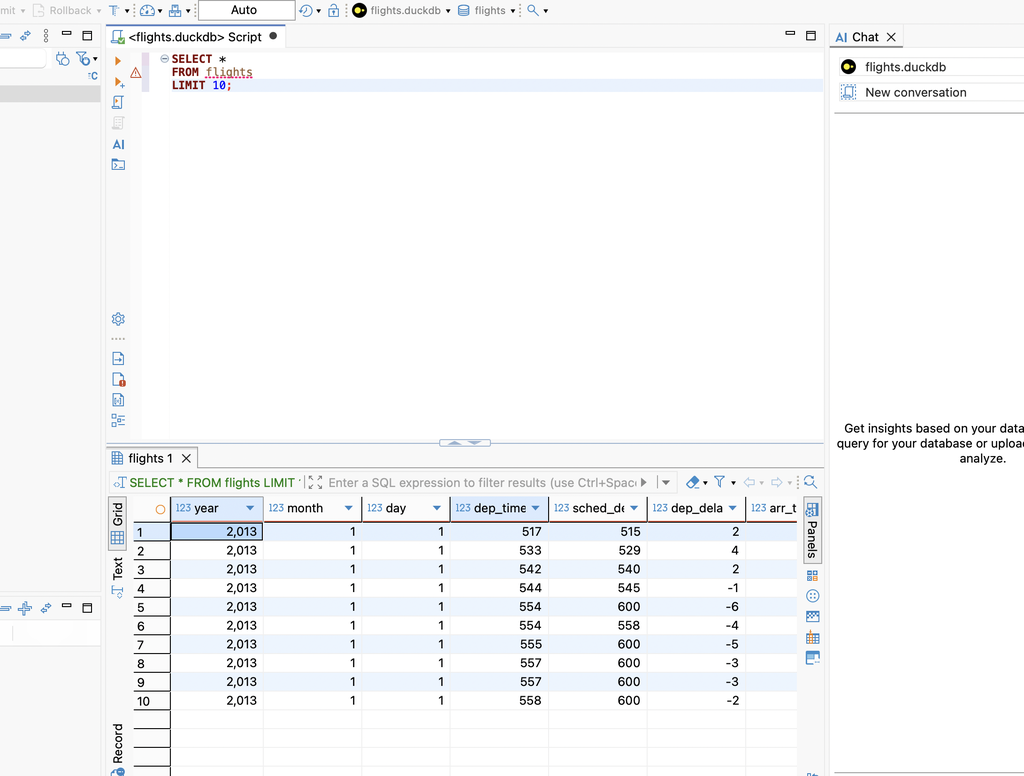

## Part b

- Part b
  - This query counts the number of flights for each carrier and sorts the results from largest to smallest.

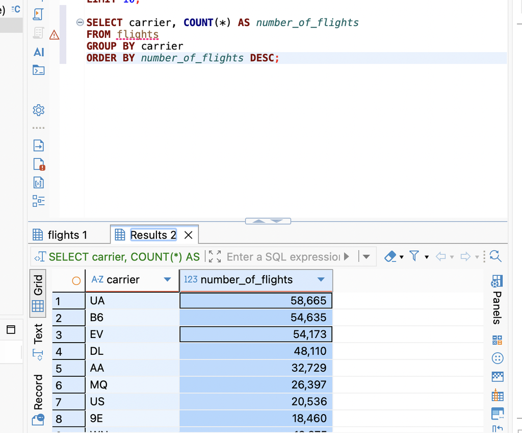

## Part c

- Part c
  - This screenshot shows query that calculates the average departure delay for each month. It groups flights by month and uses `AVG(dep_delay)` to calculate the average delay in minutes. The results are displayed in month order, from January to December.

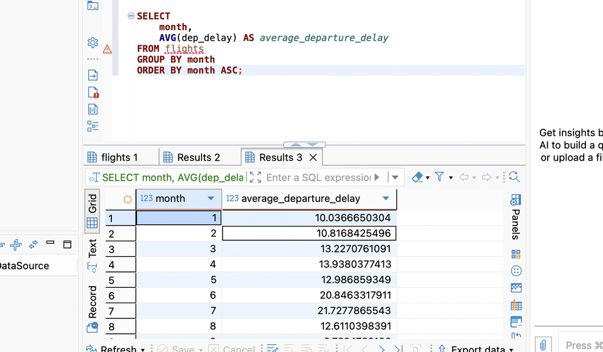

## Part d

- Part d
  - This screenshot shows the query in SQL that counts the number of flights for each route, using both the origin and destination airports. It groups flights by `origin` and `dest`, sorts the routes from the most flights to the fewest, and displays only the top 10 routes.

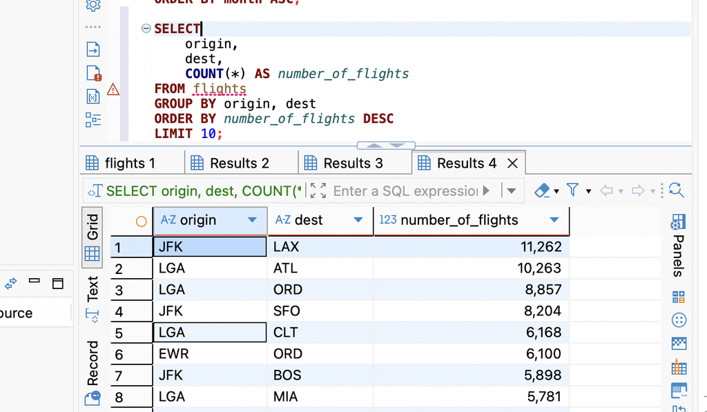

## Part e

- Part e
  - Exported the results of part b from dbeaver.

```r
read.csv("flights_by_carrier.csv")
```

```
   carrier number_of_flights
1       UA             58665
2       B6             54635
3       EV             54173
4       DL             48110
5       AA             32729
6       MQ             26397
7       US             20536
8       9E             18460
9       WN             12275
10      VX              5162
11      FL              3260
12      AS               714
13      F9               685
14      YV               601
15      HA               342
16      OO                32
```